# workout1-jeremy-martinez

Jeremy Martinez 10/18/2019

This report is about the different types of storms that were observed between 2010-2015. To start we will be looking at the number of each storm that occurred in each year

```r
require("dplyr")
count(group_by(ibtracs,season))
```

```
## # A tibble: 6 x 2
## # Groups:   season [6]
##   season     n
##    <int> <int>
## 1   2010  2787
## 2   2011  3255
## 3   2012  3307
## 4   2013  3299
## 5   2014  3537
## 6   2015  3810
```

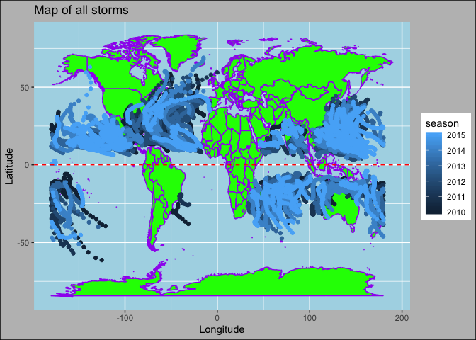

```r
require("ggplot2")
library("ggplot2")
ibtracs2=na.omit(ibtracs)
mapWorld= borders("world", colour="purple", fill="green")
ggplot(data = ibtracs2, aes(longitude,latitude,col=season))+mapWorld+geom_point()+ggtitle("Map of all storms")+xlab("Longitude")+ylab('Latitude')+
geom_hline(yintercept = 0, col='red', linetype=2)+
theme(plot.background = element_rect(fill='gray', colour='black'), panel.background = element_rect(fill = "lightblue",
colour = "lightblue",size = 0.5, linetype = "solid"))
```

From this we can see that the amount of storms in the northern hemisphere are alot more that than the storms that occur in the southern hemisphere. But the question is, do the total number of storms, occur uniformly each year or is there more storm activity during certain months. In the histogram provided below we can see that all of the storms grouped together by month shows that most of the storms tend to happen within the month of September. This shows that more activity tends to happen in certain months then compared to being uniformly throughout the years.

```r
# Add month column
library(lubridate)
```

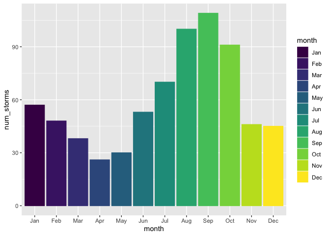

```r
ibtrac_months <- mutate(ibtracs, month = month(iso_time, label = TRUE))
unique_months <- summarise(group_by(ibtrac_months, month), num_storms = n_distinct(serial_num))
ggplot(unique_months, aes(month, num_storms, col=month, fill=month)) + geom_histogram(stat = "identity")
```

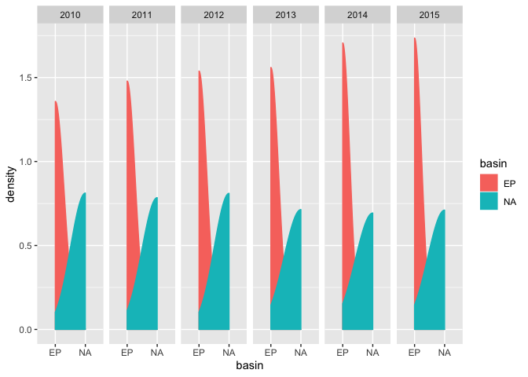

```r
ibtracs_basin=filter(select(ibtracs,name,season,basin), basin=="EP" | basin=="NA")
ggplot(data = ibtracs_basin, aes(x=basin,col=basin, fill= basin))+geom_density()+facet_grid(.~season)
```

In the images provided below, we can see the different nature of storms, as well as there wind speeds and pressure. In the first image we can see all the storms over several months between 2010-2015. In the following graph, this graph looks at the different storms over a 6 year period and how the patterns of these storms have evolved. In the final graph we can see the how the storms have changed over the course of 12 months over a 6 year period.

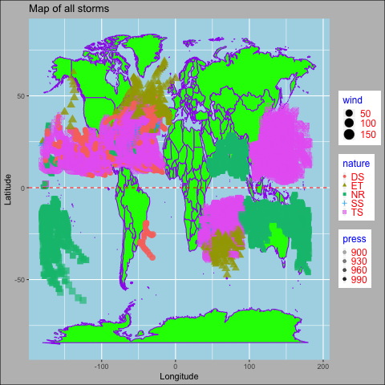

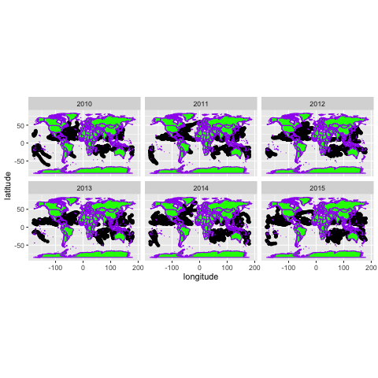

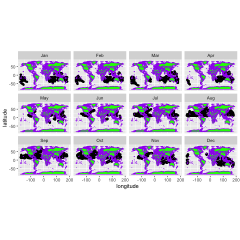